## Machine learning project"

### Introduction

Using devices such as Jawbone Up, Nike FuelBand, and Fitbit it is now possible to collect a large amount of data about personal activity relatively inexpensively. These type of devices are part of the quantified self movement - a group of enthusiasts who take measurements about themselves regularly to improve their health, to find patterns in their behavior, or because they are tech geeks. One thing that people regularly do is quantify how much of a particular activity they do, but they rarely quantify how well they do it. In this project, the goal is to use data from accelerometers on the belt, forearm, arm, and dumbell of 6 participants. They were asked to perform barbell lifts correctly and incorrectly in 5 different ways

### Downloading data for hte project

```r
download.file("http://d396qusza40orc.cloudfront.net/predmachlearn/pml-training.csv",
              "train_set.csv",mode="wb")
download.file("http://d396qusza40orc.cloudfront.net/predmachlearn/pml-testing.csv",
              "test_set.csv", mode="wb")

train_set <- read.csv("train_set.csv",na.strings=c("NA","#DIV/0!", ""), row.names = 1)
test_set <- read.csv("test_set.csv",na.strings=c("NA","#DIV/0!", ""), row.names = 1)

dim(train_set)
```

```
## [1] 19622   159
```

```r
dim(test_set)
```

```
## [1]  20 159
```

```r
table(train_set$classe)
```

```
##
##    A    B    C    D    E
## 5580 3797 3422 3216 3607
```

### Data Processing

First round of data processing will include cleaning data.

```r
##check for NAs
nasPerColumn <- apply(train_set, 2, function(x) length(which(is.na(x))))
nasPerColumn
```

[output not shown]

[output cut: 51 more lines]

[output not shown]

```r
##remove columns that contain mostly NA values (90%)
train_set <- train_set[,which(nasPerColumn <  nrow(train_set)*0.9)]

library(caret)
##remove near zero values
nearZeroColumns <- nearZeroVar(train_set, saveMetrics = TRUE)
train_set <- train_set[, nearZeroColumns$nzv==FALSE]

##subset the taining set to only predictor columns
train_set   <-train_set[,-c(1:7)]
test_set <-test_set[,-c(1:7)]

##Classe as factor
train_set$classe <- factor(train_set$classe)
```

Now let’s do preprocessing for the model training

```r
library(caret)
set.seed(23232)
inTrain <- createDataPartition(train_set$classe, p=0.75, list = FALSE)
train <- train_set[inTrain,]
test <- train_set[-inTrain,]
```

### Model Training and validation

First, we will build descision tree model.

```r
library(randomForest)
```

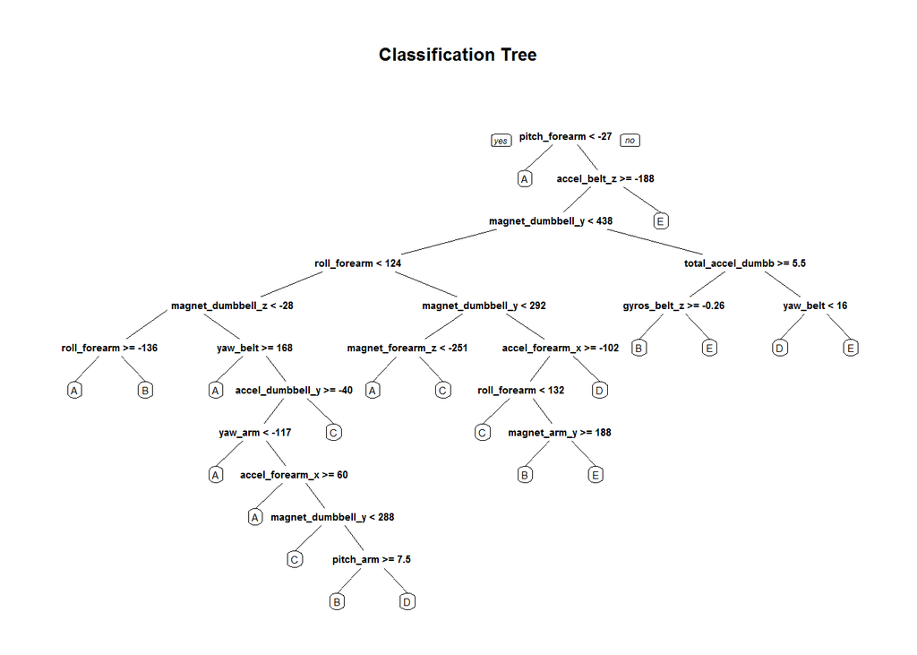

```r
library(rpart)
library(rpart.plot)

firstmodel <- rpart(classe ~ ., data=train, method="class")
prediction <- predict(firstmodel, test, type = "class")
rpart.plot(firstmodel, main="Classification Tree")
```

```r
##review confusin matrix
confusionMatrix(prediction, test$classe)
```

```
## Confusion Matrix and Statistics
##
##           Reference
## Prediction    A    B    C    D    E
##          A 1256  179   36   62   64
##          B   37  423   66   88  133
##          C   38  211  732  209  219
##          D   49  104   14  407   61
##          E   15   32    7   38  424
##
## Overall Statistics
##
##                Accuracy : 0.6611
##                  95% CI : (0.6477, 0.6743)
##     No Information Rate : 0.2845
##     P-Value [Acc > NIR] : < 2.2e-16
##
##                   Kappa : 0.5695
##  Mcnemar's Test P-Value : < 2.2e-16
##
## Statistics by Class:
##
##                      Class: A Class: B Class: C Class: D Class: E
## Sensitivity            0.9004  0.44573   0.8561  0.50622  0.47059
## Specificity            0.9028  0.91808   0.8328  0.94439  0.97702
## Pos Pred Value         0.7865  0.56627   0.5195  0.64094  0.82171
## Neg Pred Value         0.9580  0.87347   0.9648  0.90700  0.89129
## Prevalence             0.2845  0.19352   0.1743  0.16395  0.18373
## Detection Rate         0.2561  0.08626   0.1493  0.08299  0.08646
## Detection Prevalence   0.3257  0.15232   0.2873  0.12949  0.10522
## Balanced Accuracy      0.9016  0.68191   0.8445  0.72530  0.72380
```

Now we will build random forest model.

```r
scondmodel <- randomForest(classe ~ ., data=train, method="class")
prediction <- predict(scondmodel, test, type = "class")

##review confusin matrix
confusionMatrix(prediction, test$classe)
```

```
## Confusion Matrix and Statistics
##
##           Reference
## Prediction    A    B    C    D    E
##          A 1392    7    0    0    0
##          B    2  939    5    0    0
##          C    0    3  849   18    0
##          D    0    0    1  786    3
##          E    1    0    0    0  898
##
## Overall Statistics
##
##                Accuracy : 0.9918
##                  95% CI : (0.9889, 0.9942)
##     No Information Rate : 0.2845
##     P-Value [Acc > NIR] : < 2.2e-16
##
##                   Kappa : 0.9897
##  Mcnemar's Test P-Value : NA
##
## Statistics by Class:
##
##                      Class: A Class: B Class: C Class: D Class: E
## Sensitivity            0.9978   0.9895   0.9930   0.9776   0.9967
## Specificity            0.9980   0.9982   0.9948   0.9990   0.9998
## Pos Pred Value         0.9950   0.9926   0.9759   0.9949   0.9989
## Neg Pred Value         0.9991   0.9975   0.9985   0.9956   0.9993
## Prevalence             0.2845   0.1935   0.1743   0.1639   0.1837
## Detection Rate         0.2838   0.1915   0.1731   0.1603   0.1831
## Detection Prevalence   0.2853   0.1929   0.1774   0.1611   0.1833
## Balanced Accuracy      0.9979   0.9938   0.9939   0.9883   0.9982
```

We see that reandom forest model accuracy is better then the decision tree model accuracy, so we should be using that model to predict results for the test_set file.

### Test Set predictions

```r
test_predictions <- predict(scondmodel, test_set, type="class")

##the list of answers
test_predictions
```

```
##  1  2  3  4  5  6  7  8  9 10 11 12 13 14 15 16 17 18 19 20
##  B  A  B  A  A  E  D  B  A  A  B  C  B  A  E  E  A  B  B  B
## Levels: A B C D E
```

Creating submission files.

```r
# Write files for submission
pml_write_files = function(x){
  n = length(x)
  for(i in 1:n){
    filename = paste0("problem_id_",i,".txt")
    write.table(x[i],file=filename,quote=FALSE,row.names=FALSE,col.names=FALSE)
  }
}

pml_write_files(test_predictions)
```